# S2 Instalación de sistemas contra incendios

## **Introducción**

### Relevancia

Contar con una base de datos que recolecta información sobre edificios en construcción o planificación para empresas que instalan sistemas contra incendios y genere una serie de análisis estadísticos de conveniencia a partir de ellos, es de suma importancia en el ámbito de la seguridad contra incendios para las empresas que instalan estos sistemas en el sector construcción .Nuestra base de datos proporciona a las empresas de sistemas contra incendios una valiosa herramienta para identificar y establecer contactos tempranos con los propietarios o desarrolladores de edificios para darle una mejor idea de cuales son los proyectos que tienen que tener mayor prioridad. Esto les brinda la oportunidad de presentar sus servicios y soluciones desde las primeras etapas del proyecto, lo que puede resultar en una relación comercial sólida y duradera. Al estar involucradas desde el principio, las empresas pueden ofrecer asesoramiento especializado y trabajar en estrecha colaboración con los responsables del proyecto para diseñar e implementar sistemas contra incendios efectivos y conformes con las normativas aplicables. En resumen, una base de datos que recolecta información sobre edificios en construcción o planificación para empresas de sistemas contra incendios es altamente relevante en el ámbito de la seguridad y el crecimiento empresarial.

### Objetivos

- Identificar y contactar con empresas constructoras que están trabajando en la mayor cantidad de proyectos, con el fin de establecer relaciones comerciales y ofrecer servicios de instalación de sistemas contra incendios. Esto permitirá a nuestra empresa maximizar las oportunidades de negocio y aumentar nuestra participación en el mercado de la seguridad contra incendios.
- Identificar la etapa de los edificios (planificación o construcción) para determinar cuáles tienen calendarios de entrega ajustados y probablemente ya hayan contratado a otra empresa de sistemas contra incendios. Esto nos permitirá focalizar nuestros esfuerzos en los edificios que aún no hayan contratado dichos servicios, maximizando así nuestras oportunidades de negocio.
- Determinar qué edificios son más convenientes para trabajar, considerando una combinación de factores que incluyen el área del edificio, la cantidad de departamentos por piso y la cantidad de detectores que se instalarán. Buscamos identificar aquellos proyectos que presenten un alto potencial de ingresos en relación con la cantidad de trabajo y recursos necesarios. Al evaluar estos factores, podremos seleccionar los proyectos que nos brinden mayores ganancias en un tiempo óptimo, optimizando nuestra rentabilidad y eficiencia operativa.

### Contexto

Este proyecto recopila información sobre edificios en construcción o en planificación, la cual adquiere una gran relevancia debido al crecimiento y desarrollo urbano continuo que experimenta el país. Esta expansión conlleva un aumento significativo en la construcción de diversos tipos de edificios, incluyendo residenciales, comerciales e industriales. A medida que se llevan a cabo más proyectos de construcción, surge la necesidad de garantizar la seguridad contra incendios en estos edificios, lo que aumenta la importancia de contar con información precisa y actualizada sobre cada proyecto.

La base de datos es especialmente valiosa para las empresas especializadas en la instalación de sistemas contra incendios. Les brinda una visión panorámica de los edificios en construcción o planificación en todo el país, permitiéndoles identificar oportunidades comerciales estratégicas. Al tener acceso a datos detallados sobre la ubicación, tamaño, etapa de construcción y otros aspectos relevantes de los proyectos, estas empresas pueden evaluar de manera efectiva cuáles edificios son más convenientes para contactar y presentar sus soluciones en seguridad contra incendios. Además, en el contexto normativo peruano, existen requisitos específicos para la instalación de sistemas contra incendios en edificios de determinadas características y tamaños. La base de datos proporciona a las empresas información crucial para adaptar su enfoque y ofrecer soluciones que cumplan con las regulaciones locales. Esto garantiza que los sistemas contra incendios se implementen de manera adecuada y contribuye a la seguridad de los ocupantes de los edificios.

## **Datos**

### Recolección de datos

La recolección de datos se dio con la formación de una base de datos a partir de otras bases de datos que pertenecen a la empresa en la que uno de los integrantes del grupo trabaja, pero en esa recopilación, quedaron muchos espacios vacíos, y para rellenarlos contactamos con las inmobiliarias necesarias vía llamada telefónica o mensajes directos.

### Variables

| Variable | Tipo | Clase | Restricciones |
| --- | --- | --- | --- |
| Cliente(Inmobiliaria o constructora) | Categórica | Nominal | No se puede realizar operaciones aritméticas, solo se puede seleccionar opciones dadas. |
| Tipo de edificación | Categórica | Nominal | No se puede realizar operaciones aritméticas, solo puede seleccionar opciones dadas. |
| Distrito | Categórica | Nominal | No se puede usar descriptores de posición, solo puede seleccionar opciones dadas. |
| Etapa de la Edificación | Categórica | Ordinales | No se puede usar descriptores de posición, solo puede seleccionar opciones dadas. |
| Cantidad de pisos | Cuantitativa | Discreta | Solo acepta números enteros entre 1 y 34. |
| Cantidad de sótanos | Cuantitativa | Discreta | Solo acepta números enteros entre 0 y 7. |
| Departamentos por piso | Cuantitativa | Discretas | Solo acepta números enteros entre 1 y 15. |
| Cantidad de detectores de temperatura | Cuantitativa | Discretas | Solo acepta números enteros entre 0 y 2000. |
| Cantidad de detectores de humo | Cuantitativa | Discretas | Solo acepta números enteros entre 1 y 600. |
| Área superficial de los edificios (m<sup>2</sup>) | Cuantitativa | Continuas | Solo acepta números entre 200 y 2500. |
| Ingreso estimado | Cuantitativa | Continuas | Solo acepta números entre 2 500 y 85 000. |

### Limpieza de base de datos

A partir de los 500 edificios que recopilamos, había que conseguir una serie de datos importantes al respecto, lamentablemente la mayoría de estos edificios no se encuentran en Internet al estar en etapas muy tempranas de desarrollo y no pudimos establecer una conexión con las constructoras o inmobiliarias a cargo, por lo tanto limpiamos todas las observaciones que quedaron con datos vacíos, que fueron aproximadamente 150, dejándonos aproximadamente con 350 observaciones limpias y listas para analizar.

- Instalación y llamado a las librerías que usaremos :

```r
packages <- c("pacman")
installed_packages <- packages%in% rownames(installed.packages())
if (any(installed_packages == FALSE)) {
  install.packages(packages[!installed_packages])
}

pacman::p_load(ggplot2, dplyr, readr,plotrix, car)
```

- Carga de nuestra base de datos :

```r
DF <- read_csv("Database.csv")
```

- Seleccionamos las variables con las que vamos a trabajar, para ello utilizamos la función “select”

```r
DB <-select(DF, CLIENTE , `TIPO DE EDIFICACIÓN` , DISTRITO , `ETAPA DE LA EDIFICACIÓN` , PISOS , SÓTANOS , `DEPARTAMENTOS POR PISO` , `CANTIDAD DE DETECTORES DE HUMO` , `CANTIDAD DE DETECTORES DE TEMPERATURA` , `ÁREA DEL EDIFICIO` , INGRESO)
```

- Luego de aplicar “unique” a cada variable se encontró un error en la variable “ETAPA DE EDIFICACION” .

```r
unique(DB$`ETAPA DE LA EDIFICACIÓN`)
```

```
## [1] "ETAPA DE CONSTRUCCION" "ETAPA DE PLANOS"       "ETAPA DE CONSTRUCCIÓN"
```

- Se procedió a corregir los errores de redacción que se presentaron durante la creación de la base de datos.

```r
DB %>% mutate(`ETAPA DE LA EDIFICACIÓN` =
        ifelse(`ETAPA DE LA EDIFICACIÓN` == "ETAPA DE CONSTRUCCION", "ETAPA DE CONSTRUCCIÓN", `ETAPA DE LA EDIFICACIÓN`
       )) -> DB
DB %>% count(`ETAPA DE LA EDIFICACIÓN`)
```

| ETAPA DE LA EDIFICACIÓN | n |
| --- | --- |
| ETAPA DE CONSTRUCCIÓN | 52 |
| ETAPA DE PLANOS | 301 |

Total de Observaciones:

- Casos completos

```r
sum(complete.cases(DB))
```

```
## [1] 353
```

- Casos incompletos

```r
sum(!complete.cases(DB))
```

```
## [1] 0
```

- Total de Variables:

```r
ncol(DB)
```

```
## [1] 11
```

## **Análisis descriptivo**

### Gráfico de barras de Clientes

```r
temp <- DB  %>% group_by(CLIENTE) %>% summarise(Total=n())
temp
```

| CLIENTE | Total |
| --- | --- |
| 3F Constructora | 3 |
| ABRIL GRUPO INMOBILIARIO | 10 |
| ACTIVA INMOBILIARIA | 1 |
| ACTUAL | 2 |
| AKAMAI SAC | 1 |
| ALBAMAR | 1 |
| ALERCES INMOBILIARIA | 1 |
| AMMA INMOBILIARIA | 1 |
| ANTARES CONTRATISTAS S.A | 1 |
| AR ARQUITECTOS | 1 |

[output cut: 153 more lines]

Al haber 163 clientes , mostrar la data en un gráfico seria imposible , por eso filtraremos la data para mostrar cuales son las empresas que tienen un mayor numero de proyectos.

```r
Tabla_C <- DB %>% group_by(CLIENTE) %>% summarise(Total=n())   %>%
    dplyr::mutate(Porcentaje = round(Total/sum(Total)*100, 1))
Tabla_C2 <- Tabla_C %>% filter (temp$Total > 4)
Tabla_C2
```

| CLIENTE | Total | Porcentaje |
| --- | --- | --- |
| ABRIL GRUPO INMOBILIARIO | 10 | 2.8 |
| ARMANDO PAREDES | 5 | 1.4 |
| ARTECO | 6 | 1.7 |
| CANTABRIA | 5 | 1.4 |
| CAPAC ASOCIADOS | 10 | 2.8 |
| EDIFICA / PRODUKTIVA | 18 | 5.1 |
| EE INMOBILIARIA | 11 | 3.1 |
| GRUPO CARAL | 8 | 2.3 |
| GRUPO INMOBILIARIO S&M SAC | 8 | 2.3 |
| INVENT | 8 | 2.3 |

[output cut: 6 more lines]

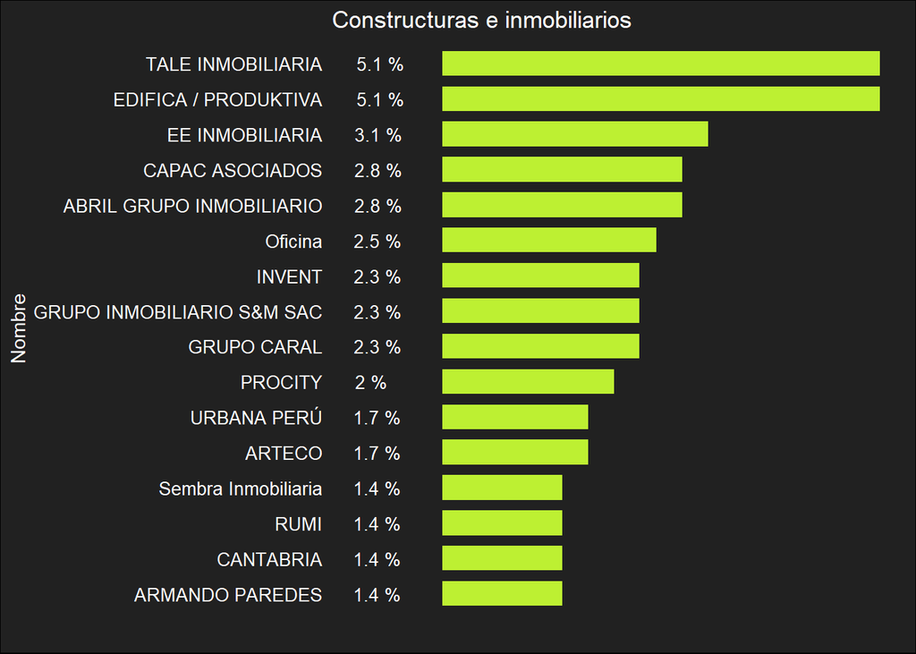

```r
ggplot(Tabla_C2) +
  geom_col(aes(reorder(CLIENTE, Total ), Porcentaje), fill='#BDF032' , width=0.7, position = position_nudge(y=1) ) +

  geom_text(aes(label=paste(Porcentaje, '%'), x=reorder(CLIENTE, Total), y=(Porcentaje/100) )  ,
            color="white",
            hjust = 0.1,
            size=3.5 ) +
  labs(title='Constructuras e inmobiliarios', x='Nombre', y='') +
  theme_minimal() +
  coord_flip()+
  theme(legend.position = 'none',
        plot.background = element_rect(fill='#212121'),
        text=element_text(color='#FFFFFF'),
        axis.text = element_text(color='#FFFFFF' , size=10),
        axis.text.x = element_blank(),
        panel.grid = element_blank())
```

Gracias a la gráfica podemos identificar que las mejores opciones son “Tale Inmobiliaria” , “Edifica/Produktiva” y “EE Inmobiliaria” . Al tener una mayor numero de proyectos , las empresas preferirían contratar una única empresa que instale sistemas contra incendios para todos sus proyectos.

### Diagrama de Tarta de los Tipos de Edificación

```r
table(DB$`TIPO DE EDIFICACIÓN`)
```

```
##
##     Oficina Residencial
##           8         345
```

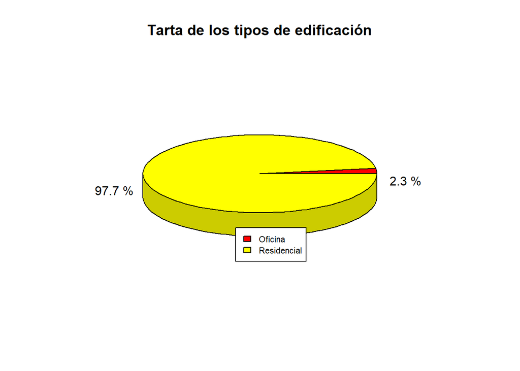

```r
Tabla_E <- DB %>% group_by(`TIPO DE EDIFICACIÓN`) %>% summarise(Total=n()) %>%
    dplyr::mutate(Porcentaje = round(Total/sum(Total)*100, 1))

pie3D(Tabla_E$Porcentaje,labels=paste(Tabla_E$Porcentaje,'%'),
      main="Tarta de los tipos de edificación",
      col = heat.colors(length(Tabla_E$Porcentaje)),
      labelcex = 0.99)
legend(1,0.7,legend=Tabla_E$`TIPO DE EDIFICACIÓN`,cex=0.7,yjust=4.7, xjust = 2,
       fill = heat.colors(length(Tabla_E$Porcentaje)))
```

A partir de la gráfica se puede observar que el 97.7% de las edificaciones son Residenciales, esto es importante para el negocio de instalación de sistema contra incendios. Porque se podrá obtener una mayor ganancia cuando se trabaje con las residenciales.

### Gráfico de barra de los distritos.

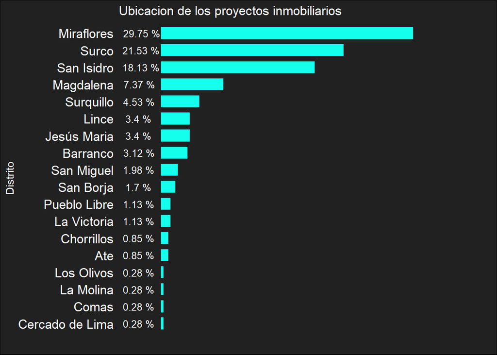

```r
Tabla_D <- DB %>% group_by(DISTRITO) %>% summarise(Total=n()) %>%
    dplyr::mutate(Porcentaje = round(Total/sum(Total)*100, 2))

ggplot(Tabla_D) +
  ylim(c(0,40))+
  geom_col(aes(reorder(DISTRITO, Total ), Porcentaje), fill='#14FFEC' , width=0.7, position = position_nudge(y=3) ) +

  geom_text(aes(label=paste(Porcentaje, '%'), x=reorder(DISTRITO, Total), y=(Porcentaje/100) )  ,
            color="white",
            hjust = 0.4,
            size=3.5 ) +
  labs(title='Ubicacion de los proyectos inmobiliarios', x='Distrito', y='') +
  theme_minimal() +
  coord_flip()+
  theme(legend.position = 'none',
        plot.background = element_rect(fill='#212121'),
        text=element_text(color='#FFFFFF'),
        axis.text = element_text(color='#FFFFFF' , size=13),
        axis.text.x = element_blank(),
        panel.grid = element_blank())
```

Se puede observar que la mayor cantidad de proyectos inmobiliarios se encuentran en los distritos de Miraflores, Surco y San Isidro respectivamente.

```r
Tabla_D %>% filter (Porcentaje > 18)
```

| DISTRITO | Total | Porcentaje |
| --- | --- | --- |
| Miraflores | 105 | 29.75 |
| San Isidro | 64 | 18.13 |
| Surco | 76 | 21.53 |

### Gráfico de barras de las etapas de las edificaciones.

```r
table(DB$`ETAPA DE LA EDIFICACIÓN`)
```

```
##
## ETAPA DE CONSTRUCCIÓN       ETAPA DE PLANOS
##                    52                   301
```

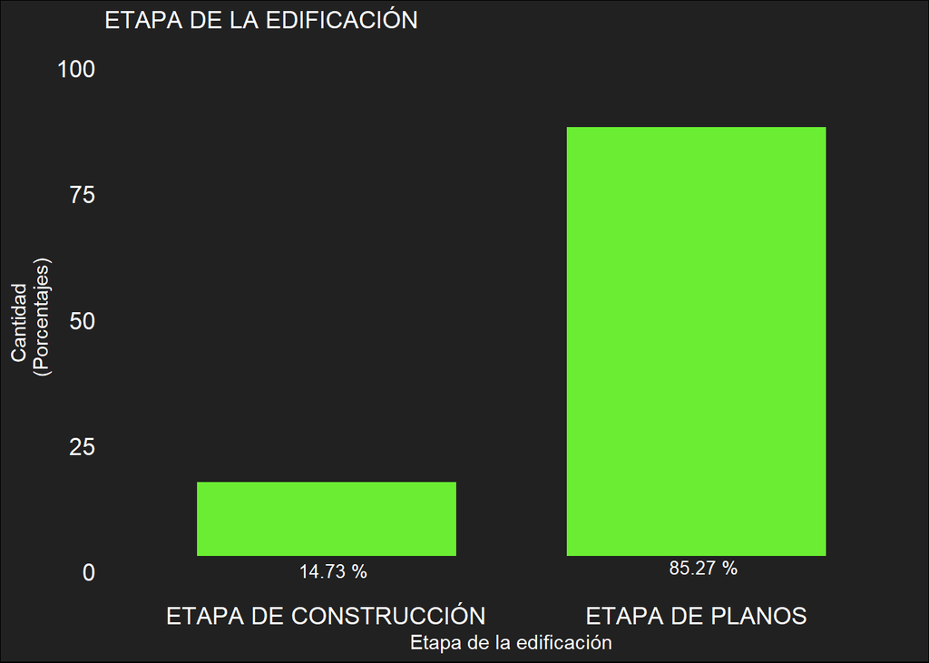

```r
Tabla_F <- DB %>% group_by(`ETAPA DE LA EDIFICACIÓN`) %>% summarise(Total=n()) %>%
    dplyr::mutate(Porcentaje = round(Total/sum(Total)*100, 2))

ggplot(Tabla_F) +
  ylim(c(0,100))+
  geom_col(aes(`ETAPA DE LA EDIFICACIÓN`, Porcentaje), fill='#6AED32' , width=0.7, position = position_nudge(y=3) ) +

  geom_text(aes(label=paste(Porcentaje, '%'), x=`ETAPA DE LA EDIFICACIÓN`, y=(Porcentaje/100) )  ,
            color="white",
            hjust = 0.4,
            size=3.5 ) +
  labs(title='ETAPA DE LA EDIFICACIÓN', x='Etapa de la edificación', y='Cantidad \n (Porcentajes)') +
  theme_minimal() +
  theme(legend.position = 'none',
        plot.background = element_rect(fill='#212121'),
        text=element_text(color='#FFFFFF'),
        axis.text = element_text(color='#FFFFFF' , size=13),
        panel.grid = element_blank())
```

Se puede observar en el gráfico que la mayoría de las edificaciones en encuentran en la etapa de planos, esto es muy favorable para los objetivos del proyecto ya que al no estar con limites de tiempo tan estrictos, las empresas que instalan equipos y sistemas pueden tomarse el tiempo de hacer una buena presentación y ofrecer precios competitivos.

### Histograma de la cantidad de pisos.

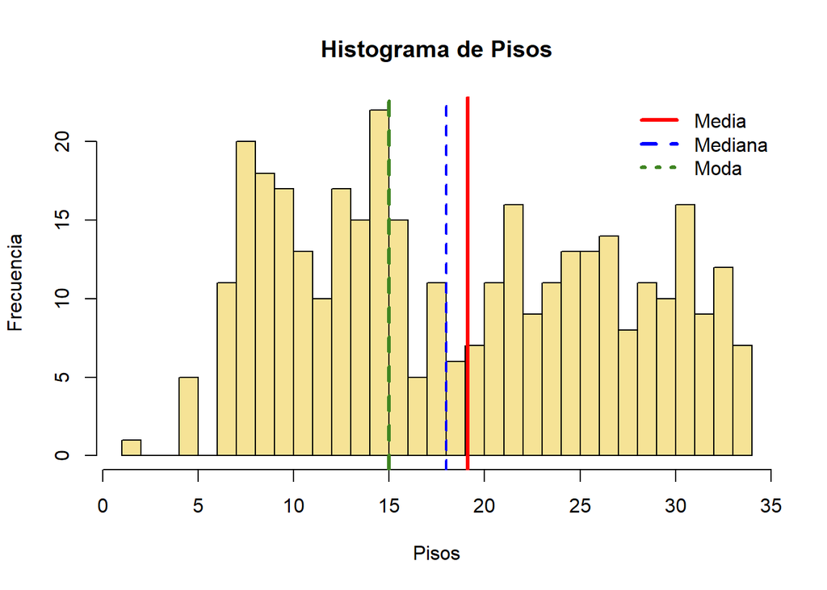

```r
prom <- round(mean(DB$PISOS),digits= 2)
med <- round(median(DB$PISOS),digits= 2)
moda1 <- function(x) {return(as.numeric(names(which.max(table(x)))))}
moda <- moda1(DB$PISOS)
hist(DB$PISOS,breaks = 34, col= '#F6E396' , main = "Histograma de Pisos",xlab= "Pisos", ylab= "Frecuencia" )
abline(v = prom,col= "red", lwd=3)
abline(v = med, col = "blue", lwd=2, lty = 2)
abline(v = moda,col= '#3F8522', lwd=3,lty = 2.5)
legend("topright",bty= "n", legend = c("Media","Mediana","Moda"),col = c("red", "blue",'#3F8522'),lwd =3, lty= 1:3)
```

Este gráfico nos indica que la cantidad de pisos esta uniformemente distribuida, por lo que las empresas se encontraran con todo tipo de proyectos para afrontar y no deberían hacer un único modelo de trabajo porque se verán perjudicados a la hora de buscar nuevos proyectos.

```r
summary(DB$PISOS)
```

```
##    Min. 1st Qu.  Median    Mean 3rd Qu.    Max.
##    1.00   12.00   18.00   19.13   26.00   34.00
```

### Histograma de la cantidad de sótanos.

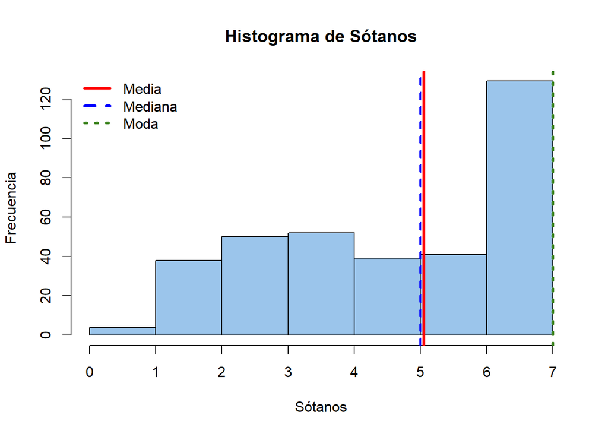

```r
moda1 <- function(x) {return(as.numeric(names(which.max(table(x)))))}
moda <- moda1(DB$SÓTANOS)
hist(DB$SÓTANOS,breaks = 7, col= '#9BC5EB' , main = "Histograma de Sótanos",xlab= "Sótanos", ylab= "Frecuencia" )
abline(v = round(mean(DB$SÓTANOS),digits= 2),col= "red", lwd=3)
abline(v = round(median(DB$SÓTANOS),digits= 2), col = "blue", lwd=2, lty = 2)
abline(v = moda,col= "#3F8522", lwd=3,lty = 3)
legend("topleft",bty= "n", legend = c("Media","Mediana","Moda"),col = c("red", "blue","#3F8522"),lwd =3, lty= 1:3)
```

```r
summary(DB$SÓTANOS)
```

```
##    Min. 1st Qu.  Median    Mean 3rd Qu.    Max.
##   0.000   3.000   5.000   5.045   7.000   7.000
```

### Boxplot de la cantidad de detectores de humo.

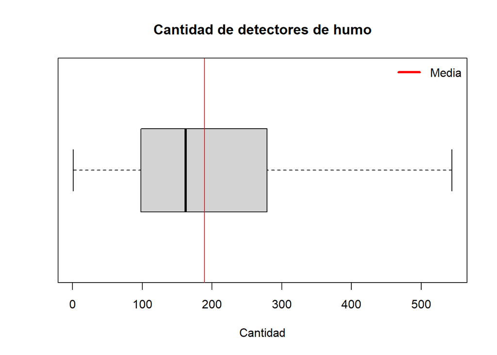

```r
boxplot(DB$`CANTIDAD DE DETECTORES DE HUMO`,main="Cantidad de detectores de humo",horizontal=TRUE,xlab="Cantidad")
abline(v=mean(DB$`CANTIDAD DE DETECTORES DE HUMO`),col="red")
legend("topright",bty= "n", legend = c("Media"),col = c("red"),lwd =3, lty= 1:3)
```

```r
summary(DB$`CANTIDAD DE DETECTORES DE HUMO`)
```

```
##    Min. 1st Qu.  Median    Mean 3rd Qu.    Max.
##     1.0    98.0   162.0   189.4   279.0   544.0
```

### Boxplot de la cantidad de detectores de temperatura.

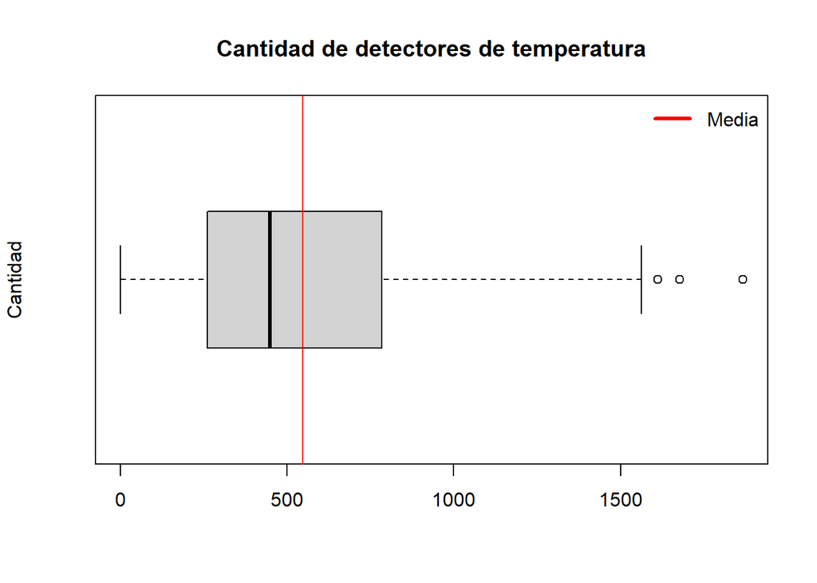

```r
boxplot(DF$`CANTIDAD DE DETECTORES DE TEMPERATURA`,main="Cantidad de detectores de temperatura",horizontal=TRUE,ylab="Cantidad")
abline(v=mean(DB$`CANTIDAD DE DETECTORES DE TEMPERATURA`),col="red")
legend("topright",bty= "n", legend = c("Media"),col = c("red"),lwd =3, lty= 1:3)
```

```r
summary(DB$`CANTIDAD DE DETECTORES DE TEMPERATURA`)
```

```
##    Min. 1st Qu.  Median    Mean 3rd Qu.    Max.
##     0.0   261.0   448.0   546.8   784.0  1867.0
```

### Histograma del tamaño de construccion del edificio.

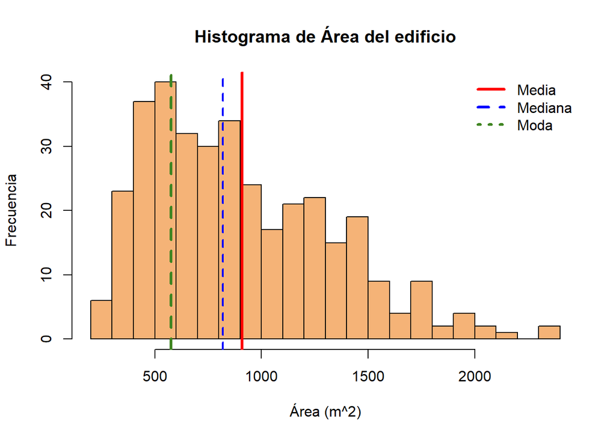

```r
moda1 <- function(x) {return(as.numeric(names(which.max(table(x)))))}
moda <- moda1(DB$`ÁREA DEL EDIFICIO`)
prom <- round(mean(DB$`ÁREA DEL EDIFICIO`),digits= 2)
med <- round(median(DB$`ÁREA DEL EDIFICIO`),digits= 2)
hist(DB$`ÁREA DEL EDIFICIO`,breaks = 20, col= "#F5B377" , main = "Histograma de Área del edificio",xlab= "Área (m^2)", ylab= "Frecuencia" )
abline(v = prom,col= "red", lwd=3)
abline(v = med, col = "blue", lwd=2, lty = 2)
abline(v = moda,col= '#3F8522', lwd=3,lty = 2.5)
legend("topright",bty= "n", legend = c("Media","Mediana","Moda"),col = c("red", "blue",'#3F8522'),lwd =3, lty= 1:3)
```

Al ser Lima una ciudad densamente poblada, los espacios que existen para construcciones nuevas no son muy amplios, por lo tanto los edificios que se construyen tendrán un área muy considerable.

```r
summary(DB$`ÁREA DEL EDIFICIO`)
```

```
##    Min. 1st Qu.  Median    Mean 3rd Qu.    Max.
##   228.0   576.0   820.0   908.5  1220.0  2400.0
```

### Boxplot del Ingreso monetario

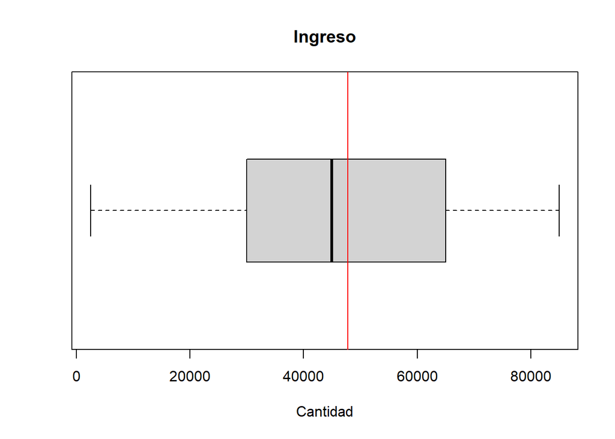

```r
boxplot(DF$INGRESO,main="Ingreso",horizontal=TRUE,xlab="Cantidad")
abline(v=mean(DF$INGRESO),col="red")
```

El ingreso estimado también es uniformemente distribuido y podemos concluir que si se relaciona bien con la cantidad de proyectos que cada empresa podrá realizar simultáneamente sin perdidas significativas.

```r
summary(DB$INGRESO)
```

```
##    Min. 1st Qu.  Median    Mean 3rd Qu.    Max.
##    2500   30000   45000   47819   65000   85000
```

### Comparación entre la cantidad de detectores de humo y el número de departamentos por piso.

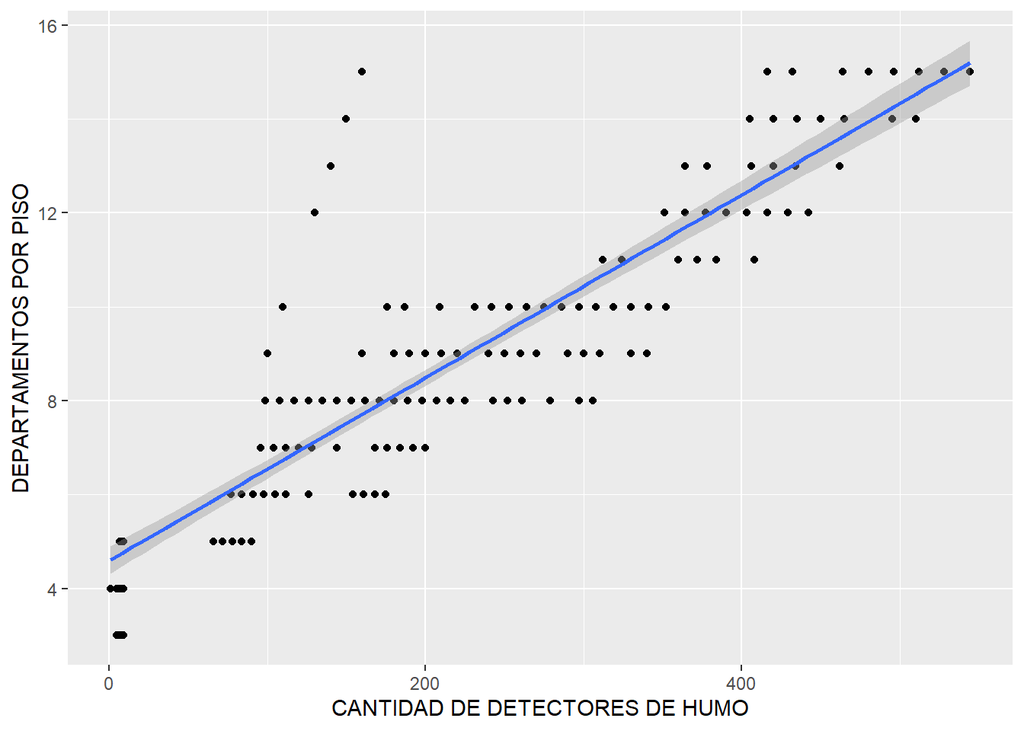

```r
ggplot(data = DB,
       mapping = aes(y = `DEPARTAMENTOS POR PISO`, x = `CANTIDAD DE DETECTORES DE HUMO`)) +
  geom_point()+
  geom_smooth(formula = y ~ x,method = "lm")
```

La recta de tendencia sugiere que existe una asociación positiva entre las variables. A mayor cantidad de departamento por piso en una edificación, mayor sera la cantidad de detectores de humo que presentara esta.

### Comparación entre la cantidad de detectores de temperatura y el número de sótanos.

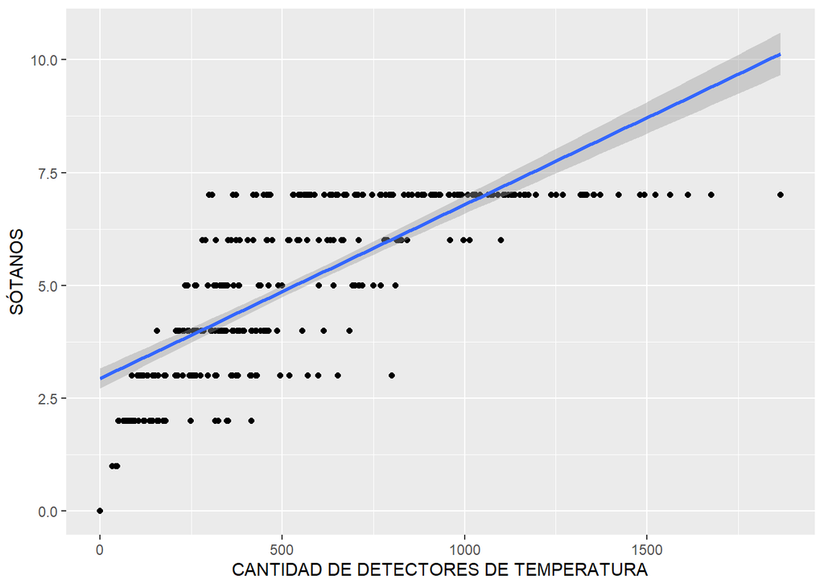

```r
ggplot(data = DB,
       mapping = aes(y = SÓTANOS, x = `CANTIDAD DE DETECTORES DE TEMPERATURA`)) +
  geom_point()+
  geom_smooth(formula = y ~ x,method = "lm")
```

La recta de tendencia sugiere que existe una asociación positiva entre las variables. A mayor cantidad de sótanos por edificación, mayor sera la cantidad de detectores de temperatura.

### Comparación entre el ingreso y el tipo de edificación.

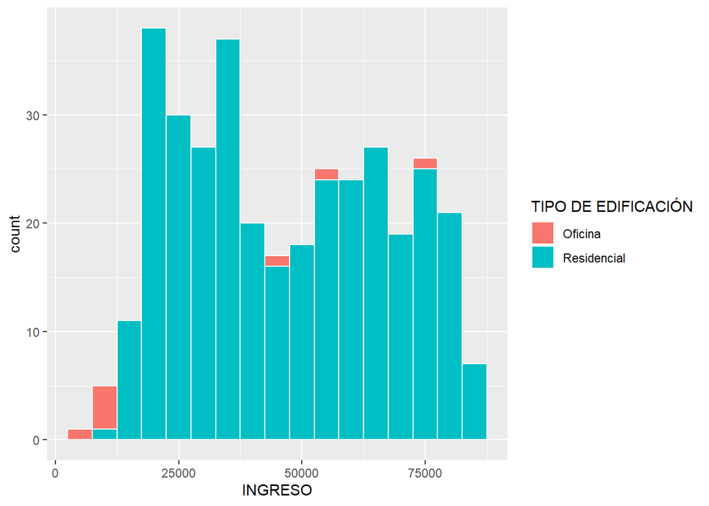

```r
ggplot(data = DB, aes(x = INGRESO, fill = `TIPO DE EDIFICACIÓN`)) +
  geom_histogram(binwidth = 5000, color = "white")
```

Podemos ver que hay más observaciones dentro del grupo de las residenciales.

Esto puede resultar más claro en un gráfico de densidad, ya que no depende de la cantidad de observaciones.

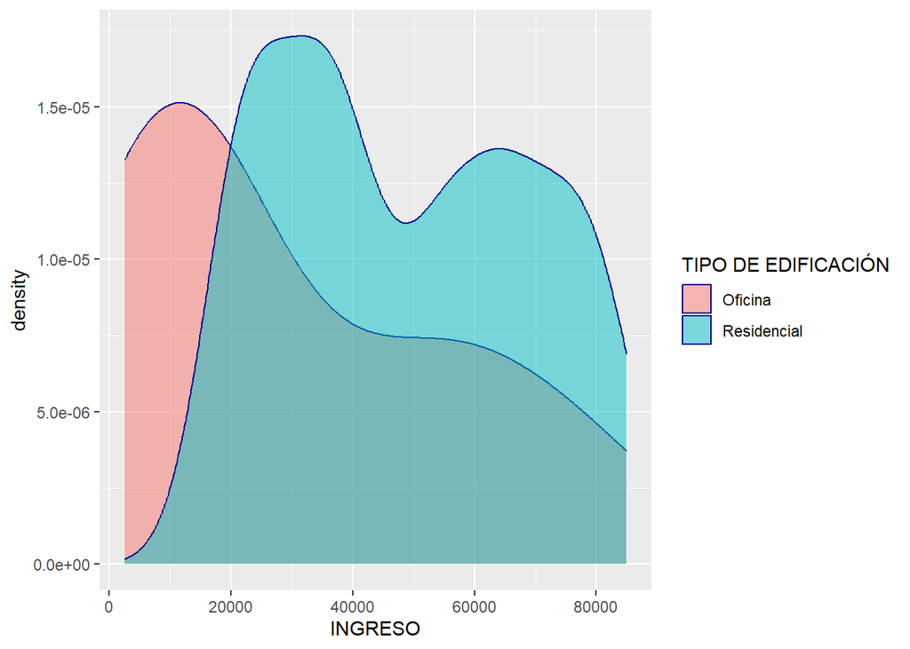

```r
ggplot(data = DB, aes(x = INGRESO, fill = `TIPO DE EDIFICACIÓN`)) +
  geom_density(alpha = 0.5, color = "darkblue")
```

## **Análisis Probabilístico**

### Probabilidad empírica

**VARIABLE 1: PISOS**

- Experimento: Seleccionar un edificio y observar la cantidad de pisos que tiene.
  - Eventos atómicos:
    - Edificio de altura baja o media: Edificios que tengan menos de 15 pisos.
    - Edificio de altura moderada o alta: Edificios que tengan 15 pisos o mas.

Imprimimos la tabla de frecuencias para ver el espacio de resultados

```r
# Obtener la tabla de frecuencia de los valores de la variable PISOS
tabla_frecuencia <- table(DB$PISOS)

# Iterar sobre los valores y frecuencias para imprimirlos de forma ordenada
for (valor in sort(unique(DB$PISOS))) {
  frecuencia <- tabla_frecuencia[as.character(valor)]
  mensaje <- paste(valor, "pisos:", frecuencia, "edificios")
  print(mensaje)
}
```

```
## [1] "1 pisos: 1 edificios"
## [1] "5 pisos: 5 edificios"
## [1] "7 pisos: 11 edificios"
## [1] "8 pisos: 20 edificios"
## [1] "9 pisos: 18 edificios"
## [1] "10 pisos: 17 edificios"
## [1] "11 pisos: 13 edificios"
## [1] "12 pisos: 10 edificios"
## [1] "13 pisos: 17 edificios"
## [1] "14 pisos: 15 edificios"
## [1] "15 pisos: 22 edificios"
## [1] "16 pisos: 15 edificios"
## [1] "17 pisos: 5 edificios"
## [1] "18 pisos: 11 edificios"
## [1] "19 pisos: 6 edificios"
## [1] "20 pisos: 7 edificios"
## [1] "21 pisos: 11 edificios"
## [1] "22 pisos: 16 edificios"
## [1] "23 pisos: 9 edificios"
## [1] "24 pisos: 11 edificios"
## [1] "25 pisos: 13 edificios"
## [1] "26 pisos: 13 edificios"
## [1] "27 pisos: 14 edificios"
## [1] "28 pisos: 8 edificios"
## [1] "29 pisos: 11 edificios"
## [1] "30 pisos: 10 edificios"
## [1] "31 pisos: 16 edificios"
## [1] "32 pisos: 9 edificios"
## [1] "33 pisos: 12 edificios"
## [1] "34 pisos: 7 edificios"
```

Asociaremos la cantidad de piso en 2 grupos porque la ley con respecto a la instalación de sistema contra incendios cambia a partir de los 15 pisos

Primero contamos cuantos edificios tienen menos de 15 pisos

```r
# Filtrar los registros con menos de 15 pisos
edificios_menos_15_pisos <- subset(DB, PISOS < 15)

# Contar el número de edificios resultantes
num_edificios_menos_15_pisos <- nrow(edificios_menos_15_pisos)

# Imprimir el resultado
print(num_edificios_menos_15_pisos)
```

```
## [1] 127
```

Luego contamos cuantos edificios tienen 15 pisos o mas

```r
# Filtrar los registros con 15 pisos o más
edificios_15_o_mas_pisos <- subset(DB, PISOS >= 15)

# Contar el número de edificios resultantes
num_edificios_15_o_mas_pisos <- nrow(edificios_15_o_mas_pisos)

# Imprimir el resultado
print(num_edificios_15_o_mas_pisos)
```

```
## [1] 226
```

Calcular la probabilidad de que estos dos eventos sucedan

```r
num_edificios_menos_15_pisos <- nrow(edificios_menos_15_pisos)
num_edificios_15_o_mas_pisos <- nrow(edificios_15_o_mas_pisos)

# Obtener el número total de edificios en la base de datos
num_total_edificios <- nrow(DB)

# Calcular la probabilidad de tener menos de 15 pisos
probabilidad_menos_15_pisos <- num_edificios_menos_15_pisos / num_total_edificios

# Calcular la probabilidad de tener 15 pisos o más
probabilidad_15_o_mas_pisos <- num_edificios_15_o_mas_pisos / num_total_edificios

# Imprimir los resultados
print(round(probabilidad_menos_15_pisos , 2))
```

```
## [1] 0.36
```

```r
print(round(probabilidad_15_o_mas_pisos , 2))
```

```
## [1] 0.64
```

La probabilidad de que un edificio escogido aleatoriamente tenga menos de 15 pisos es 0.36

La probabilidad de que un edificio escogido aleatoriamente tenga 15 pisos o mas es 0.64

**VARIABLE 2: Distrito**

- Experimento: Seleccionar un edificio y observar el distrito en el que se ubica.
  - Eventos atómicos:

```r
# Obtener los distritos únicos de la variable DISTRITO
distritos_unicos <- unique(DB$DISTRITO)

# Iterar sobre los distritos únicos e imprimirlos
for (distrito in distritos_unicos) {
  print(distrito)
}
```

```
## [1] "Miraflores"
## [1] "Jesús Maria"
## [1] "San Isidro"
## [1] "Surquillo"
## [1] "Magdalena"
## [1] "Cercado de Lima"
## [1] "Surco"
## [1] "Comas"
## [1] "Los Olivos"
## [1] "San Borja"
## [1] "La Victoria"
## [1] "San Miguel"
## [1] "Lince"
## [1] "Barranco"
## [1] "Pueblo Libre"
## [1] "Chorrillos"
## [1] "Ate"
## [1] "La Molina"
```

Nuevamente imprimimos la tabla de frecuencias para ver el espacio de resultados

```r
# Obtener la tabla de frecuencias de los distritos
tabla_frecuencias <- table(DB$DISTRITO)

# Ordenar la tabla de frecuencias en orden descendente
tabla_ordenada <- sort(tabla_frecuencias, decreasing = TRUE)

# Imprimir los distritos y sus frecuencias ordenados
for (i in 1:length(tabla_ordenada)) {
  distrito <- names(tabla_ordenada)[i]
  frecuencia <- tabla_ordenada[i]
  mensaje <- paste(distrito, ":", frecuencia, "edificios")
  print(mensaje)
}
```

```
## [1] "Miraflores : 105 edificios"
## [1] "Surco : 76 edificios"
## [1] "San Isidro : 64 edificios"
## [1] "Magdalena : 26 edificios"
## [1] "Surquillo : 16 edificios"
## [1] "Jesús Maria : 12 edificios"
## [1] "Lince : 12 edificios"
## [1] "Barranco : 11 edificios"
## [1] "San Miguel : 7 edificios"
## [1] "San Borja : 6 edificios"
## [1] "La Victoria : 4 edificios"
## [1] "Pueblo Libre : 4 edificios"
## [1] "Ate : 3 edificios"
## [1] "Chorrillos : 3 edificios"
## [1] "Cercado de Lima : 1 edificios"
## [1] "Comas : 1 edificios"
## [1] "La Molina : 1 edificios"
## [1] "Los Olivos : 1 edificios"
```

Calculamos la probabilidad de que un edificio elegido aleatoriamente se ubique en cada distrito

```r
# Obtener la tabla de frecuencias de los distritos
tabla_frecuencias <- table(DB$DISTRITO)

# Calcular el número total de edificios
num_total_edificios <- nrow(DB)

# Calcular y mostrar la probabilidad para cada distrito
for (i in 1:length(tabla_frecuencias)) {
  distrito <- names(tabla_frecuencias)[i]
  frecuencia <- tabla_frecuencias[i]
  probabilidad <- frecuencia / num_total_edificios
  mensaje <- paste(distrito, " : Probabilidad =", round(probabilidad, 4))
  print(mensaje)
}
```

```
## [1] "Ate  : Probabilidad = 0.0085"
## [1] "Barranco  : Probabilidad = 0.0312"
## [1] "Cercado de Lima  : Probabilidad = 0.0028"
## [1] "Chorrillos  : Probabilidad = 0.0085"
## [1] "Comas  : Probabilidad = 0.0028"
## [1] "Jesús Maria  : Probabilidad = 0.034"
## [1] "La Molina  : Probabilidad = 0.0028"
## [1] "La Victoria  : Probabilidad = 0.0113"
## [1] "Lince  : Probabilidad = 0.034"
## [1] "Los Olivos  : Probabilidad = 0.0028"
## [1] "Magdalena  : Probabilidad = 0.0737"
## [1] "Miraflores  : Probabilidad = 0.2975"
## [1] "Pueblo Libre  : Probabilidad = 0.0113"
## [1] "San Borja  : Probabilidad = 0.017"
## [1] "San Isidro  : Probabilidad = 0.1813"
## [1] "San Miguel  : Probabilidad = 0.0198"
## [1] "Surco  : Probabilidad = 0.2153"
## [1] "Surquillo  : Probabilidad = 0.0453"
```

### Probabilidad condicional

- Elegimos dos variables dependientes: Pisos - Ingreso

```r
# Calcular la probabilidad de A: P(A) (Edificios con más de 15 pisos)
prob_A <- sum(DB$PISOS >= 15) / nrow(DB)

# Calcular la probabilidad de B dado A: P(B|A) (Edificios con ingreso mayor a 37500 dado que tienen más de 15 pisos)
prob_B_dado_A <- sum(DB$INGRESO >= 37500 & DB$PISOS >= 15) / sum(DB$PISOS >= 15)

# Calcular la probabilidad de B: P(B) (Edificios con ingreso mayor a 37500)
prob_B <- sum(DB$INGRESO >= 37500) / nrow(DB)

# Calcular la probabilidad de A dado B: P(A|B) (Edificios con más de 15 pisos dado que tienen ingreso mayor a 37500)
prob_A_dado_B <- sum(DB$PISOS >= 15 & DB$INGRESO >= 37500) / sum(DB$INGRESO >= 37500)

# Verificar si se cumple P(B|A) = P(A) y P(A|B) = P(B)
if (prob_B_dado_A == prob_B && prob_A_dado_B == prob_A) {
  print("Los eventos Pisos - Ingreso son independientes.")
} else {
  print("Los eventos Pisos - Ingreso son dependientes.")
}
```

```
## [1] "Los eventos Pisos - Ingreso son dependientes."
```

```r
# Calcular la probabilidad de A: P(A) (Edificios con más de 20 pisos)
prob_A <- sum(DB$PISOS >= 20) / nrow(DB)

# Calcular la probabilidad de B: P(B) (Edificios con ingreso mayor a 50000)
prob_B <- sum(DB$INGRESO >= 50000) / nrow(DB)

# Calcular la probabilidad de B dado A: P(B|A) (Edificios con ingreso mayor a 50000 dado que tienen más de 20 pisos)
prob_B_dado_A <- sum(DB$INGRESO >= 50000 & DB$PISOS >= 20) / sum(DB$PISOS >= 20)

# Calcular la probabilidad de A dado B: P(A|B) (Edificios con más de 20 pisos dado que tienen ingreso mayor a 50000)
prob_A_dado_B <- sum(DB$PISOS >= 20 & DB$INGRESO >= 50000) / sum(DB$INGRESO >= 50000)

# Verificar si se cumple P(B|A) = P(B) y P(A|B) = P(A)
if (prob_B_dado_A == prob_B && prob_A_dado_B == prob_A) {
  print("Los eventos Pisos - Ingreso son independientes.")
} else {
  print("Los eventos Pisos - Ingreso son dependientes.")
}
```

```
## [1] "Los eventos Pisos - Ingreso son dependientes."
```

Al haber hecho dos pruebas, confirmamos que las variables son dependientes, esto era evidente porque el ingreso que se tendrá, depende del tamaño del edificio de una forma prácticamente lineal.

```r
# Calcular la probabilidad de A: P(A) (Edificios con área del edificio mayor o igual a 1000)
prob_A <- sum(DB$`ÁREA DEL EDIFICIO` >= 1000) / nrow(DB)

# Calcular la probabilidad de B: P(B) (Edificios con cantidad de detectores de humo mayor o igual a 500)
prob_B <- sum(DB$`CANTIDAD DE DETECTORES DE HUMO` >= 500) / nrow(DB)

# Calcular la probabilidad de B dado A: P(B|A) (Edificios con cantidad de detectores de humo mayor o igual a 500 dado que tienen área del edificio mayor o igual a 1000)
prob_B_dado_A <- sum(DB$`CANTIDAD DE DETECTORES DE HUMO` >= 500 & DB$`ÁREA DEL EDIFICIO` >= 1000) / sum(DB$`ÁREA DEL EDIFICIO` >= 1000)

# Calcular la probabilidad de A dado B: P(A|B) (Edificios con área del edificio mayor o igual a 1000 dado que tienen cantidad de detectores de humo mayor o igual a 500)
prob_A_dado_B <- sum(DB$`ÁREA DEL EDIFICIO` >= 1000 & DB$`CANTIDAD DE DETECTORES DE HUMO` >= 500) / sum(DB$`CANTIDAD DE DETECTORES DE HUMO` >= 500)

# Verificar si se cumple P(B|A) = P(B) y P(A|B) = P(A)
if (prob_B_dado_A == prob_B && prob_A_dado_B == prob_A) {
  print("Los eventos Área - Cantidad de detectores de humo son independientes.")
} else {
  print("Los eventos Área - Cantidad de detectores de humo son dependientes.")
}
```

```
## [1] "Los eventos Área - Cantidad de detectores de humo son dependientes."
```

```r
# Calcular la probabilidad de A: P(A) (Edificios con área del edificio mayor o igual a 1000)
prob_A <- sum(DB$`ÁREA DEL EDIFICIO` <= 300) / nrow(DB)

# Calcular la probabilidad de B: P(B) (Edificios con cantidad de detectores de humo mayor o igual a 500)
prob_B <- sum(DB$`CANTIDAD DE DETECTORES DE HUMO` <= 150) / nrow(DB)

# Calcular la probabilidad de B dado A: P(B|A) (Edificios con cantidad de detectores de humo mayor o igual a 150 dado que tienen área del edificio menor o igual a 300)
prob_B_dado_A <- sum(DB$`CANTIDAD DE DETECTORES DE HUMO` <= 150 & DB$`ÁREA DEL EDIFICIO` <= 300) / sum(DB$`ÁREA DEL EDIFICIO` <= 300)

# Calcular la probabilidad de A dado B: P(A|B) (Edificios con área del edificio menor o igual a 300 dado que tienen cantidad de detectores de humo menor o igual a 150)
prob_A_dado_B <- sum(DB$`ÁREA DEL EDIFICIO` <= 300 & DB$`CANTIDAD DE DETECTORES DE HUMO` <= 150) / sum(DB$`CANTIDAD DE DETECTORES DE HUMO` <= 150)

# Verificar si se cumple P(B|A) = P(B) y P(A|B) = P(A)
if (prob_B_dado_A == prob_B && prob_A_dado_B == prob_A) {
  print("Los eventos Área - Cantidad de detectores de humo son independientes.")
} else {
  print("Los eventos Área - Cantidad de detectores de humo son dependientes.")
}
```

```
## [1] "Los eventos Área - Cantidad de detectores de humo son dependientes."
```

```r
# Calcular la probabilidad de A: P(A) (Edificios con más de 15 pisos)
prob_A <- sum(DB$PISOS > 15) / nrow(DB)

# Calcular la probabilidad de B: P(B) (Edificios con ingreso mayor a 37500)
prob_B <- sum(DB$INGRESO > 37500) / nrow(DB)

# Calcular la probabilidad condicional de A dado B: P(A|B)
prob_A_dado_B <- sum(DB$PISOS > 15 & DB$INGRESO > 37500) / sum(DB$INGRESO > 37500)

# Calcular P(B|A) utilizando la fórmula de Bayes
prob_B_dado_A <- prob_A_dado_B * prob_B / prob_A

# Imprimir el resultado
print(paste("La probabilidad condicional P(B|A) es:", prob_B_dado_A))
```

```
## [1] "La probabilidad condicional P(B|A) es: 1"
```

```r
# Calcular la probabilidad de A: P(A) (Edificios con área del edificio mayor o igual a 1000)
prob_A <- sum(DB$`ÁREA DEL EDIFICIO` >= 1000) / nrow(DB)

# Calcular la probabilidad de B: P(B) (Edificios con cantidad de detectores de humo mayor o igual a 500)
prob_B <- sum(DB$`CANTIDAD DE DETECTORES DE HUMO` >= 250) / nrow(DB)

# Calcular la probabilidad condicional de A dado B: P(A|B)
prob_A_dado_B <- sum(DB$`ÁREA DEL EDIFICIO` >= 1000 & DB$`CANTIDAD DE DETECTORES DE HUMO` >= 250) / sum(DB$`CANTIDAD DE DETECTORES DE HUMO` >= 250)

# Calcular P(B|A) utilizando la fórmula de Bayes
prob_B_dado_A <- prob_A_dado_B * prob_B / prob_A

# Imprimir el resultado
print(paste("La probabilidad condicional P(B|A) es:", prob_B_dado_A))
```

```
## [1] "La probabilidad condicional P(B|A) es: 0.5625"
```

```r
# Calcular la probabilidad de A: P(A) (Edificios con área del edificio mayor o igual a 1000)
prob_A <- sum(DB$`ÁREA DEL EDIFICIO` >= 500) / nrow(DB)

# Calcular la probabilidad de B: P(B) (Edificios con cantidad de detectores de humo mayor o igual a 500)
prob_B <- sum(DB$`CANTIDAD DE DETECTORES DE HUMO` >= 100) / nrow(DB)

# Calcular la probabilidad condicional de A dado B: P(A|B)
prob_A_dado_B <- sum(DB$`ÁREA DEL EDIFICIO` >= 500 & DB$`CANTIDAD DE DETECTORES DE HUMO` >= 100) / sum(DB$`CANTIDAD DE DETECTORES DE HUMO` >= 100)

# Calcular P(B|A) utilizando la fórmula de Bayes
prob_B_dado_A <- prob_A_dado_B * prob_B / prob_A

# Imprimir el resultado
print(paste("La probabilidad condicional P(B|A) es:", prob_B_dado_A))
```

```
## [1] "La probabilidad condicional P(B|A) es: 0.829268292682927"
```

### Variable aleatoria discretas

**Etapa de edificación**

Dada la siguiente variable aleatoria :

X : Numero de proyectos que no se encuentre en la etapa de planos dentro de nuestra base de datos

Identificación de parámetros

X - Bin(p,n)

p : la probabilidad de éxito esta definida como el numero de proyectos que no se encuentre en la etapa de planificación

n : la cantidad total de los proyectos

```r
frecuencias_edi <- table(DB$`ETAPA DE LA EDIFICACIÓN`)
probabilidades <- frecuencias_edi / sum(frecuencias_edi)
probabilidades <- round(probabilidades, 3)

probabilidades[1]
```

```
## ETAPA DE CONSTRUCCIÓN
##                 0.147
```

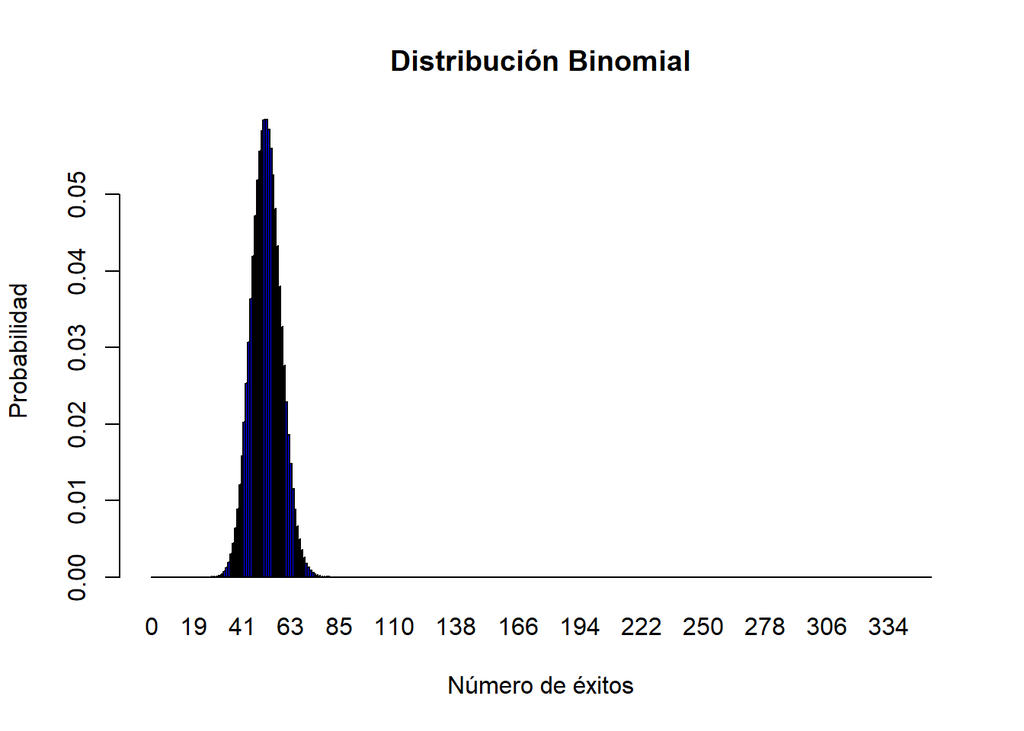

```r
result_edi <- dbinom(0:353, size = 353, prob = probabilidades[1])

# Crear el gráfico de barras
barplot(result_edi, names.arg = 0:353, xlab = "Número de éxitos", ylab = "Probabilidad",
        main = "Distribución Binomial", col = "blue")
```

```r
cat("Varianza" , varianza <- var(frecuencias_edi), "\n")
```

```
## Varianza 31000.5
```

```r
desviacion_estandar <- sqrt(varianza)
cat("Coeficiente de Variacion" , coeficiente_variacion <- (desviacion_estandar / probabilidades[1]) * 100 , "\n")
```

```
## Coeficiente de Variacion 119775.2
```

Ahora para hallar la esperanza de X :

Sera 0 cuando el proyecto se encuentra la etapa de planos Sera 1 cuando el proyecto se encuentra la etapa de construcción

```r
cat("Esperanza" , 0 * probabilidades[2] + 1 * probabilidades[1] , "\n")
```

```
## Esperanza 0.147
```

Ejemplo de aplicación :

En una feria inmobiliaria se desea conocer la probabilidad de que mas del 30% de los proyectos están en etapa de planificación. Se saben que en esta feria hay 100 proyectos.

P ( Y > 30) = P (X < 30)

```r
pbinom(30 , 100, probabilidades[1], lower.tail = T )
```

```
## [1] 0.9999725
```

El resultado obtenido durante el ejemplo es de 0.99 esto es la suma de todas la probabilidades de éxito hasta n = 30 , esto se puede observar en el gráfico anterior, pues hasta el valor 30 la probabilidad de que un proyecto no este en etapa de planificación no es alta.

**Cantidad de sensores de Temperatura**

Identificación de parámetros

X - Bin(p,n)

p : la probabilidad de éxito esta definida como el numero de proyectos que soliciten mas de 500 sensores de temperatura

n : cantidad total de nuestras proyectos

```r
temp_5<- subset(DB, DB$`CANTIDAD DE DETECTORES DE TEMPERATURA` > 500)
temp_500 <- table(temp_5$`CANTIDAD DE DETECTORES DE TEMPERATURA`)



probabilidades1 <-  sum(temp_500)/ nrow(DB)
probabilidades1 <- round(probabilidades1, 3)

probabilidades1
```

```
## [1] 0.45
```

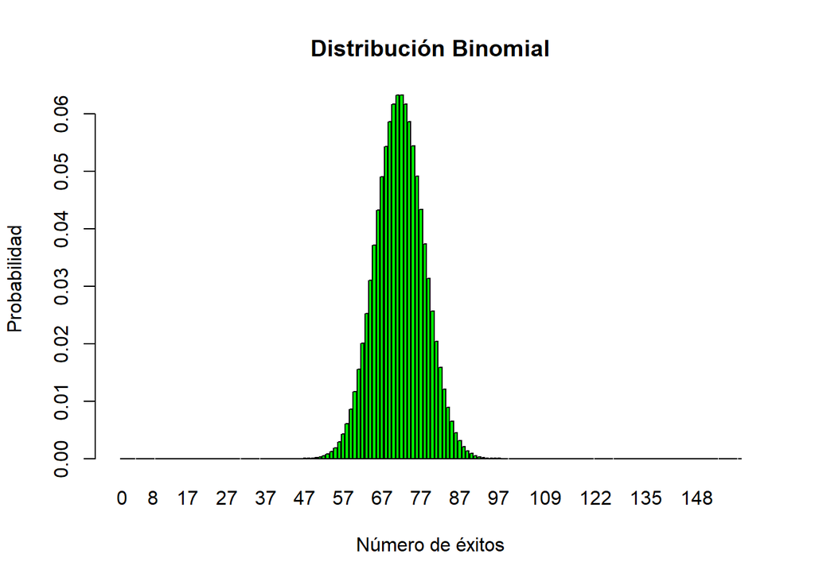

```r
result_edi <- dbinom(0:159, size = 159, prob = probabilidades1[1])

# Crear el gráfico de barras
barplot(result_edi, names.arg = 0:159, xlab = "Número de éxitos", ylab = "Probabilidad",
        main = "Distribución Binomial", col = "green")
```

```r
cat("Varianza" , varianza <- var(temp_500), "\n")
```

```
## Varianza 0.2924251
```

```r
desviacion_estandar <- sqrt(varianza)
cat("Coeficiente de Variacion" , coeficiente_variacion <- (desviacion_estandar / probabilidades) * 100 , "\n")
```

```
## Coeficiente de Variacion 367.8663 63.39548
```

Ahora para hallar la esperanza de X :

Sera 0 cuando el proyecto necesita menos de 500 sensores de Temperatura (Fracaso) Sera 1 cuando el proyecto necesita mas de 500 sensores de Temperatura (Éxito)

```r
esperanza_temp <- 0 * (1 - probabilidades1) +  1 * probabilidades1
cat("Esperanza" , esperanza_temp , "\n")
```

```
## Esperanza 0.45
```

Ejemplo de aplicación :

La empresa SecuFuego quiera saber la probabilidad de que mas del 50% de las empresas con que trabaja necesita menos de 500 sensores de temperatura. Actualmente esta trabajando con 160 empresas

P ( Y > 80) = P (X < 80)

```r
pbinom(80 , 160, probabilidades1, lower.tail = T )
```

```
## [1] 0.911356
```

```r
pbinom(80 , 160, probabilidades1, lower.tail = F )
```

```
## [1] 0.08864395
```

El resultado obtenido durante el ejemplo es de 0.91 esto es la suma de todas la probabilidades de éxito hasta n = 80 , esto se puede observar en el gráfico anterior.

### Variable aleatoria continuas

**Analizamos “Área superficial de los edificios”**

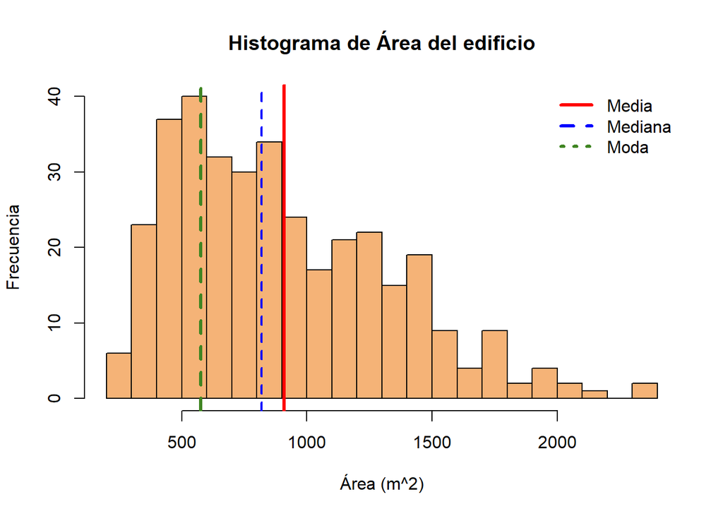

```r
moda1 <- function(x) {return(as.numeric(names(which.max(table(x)))))}
moda <- moda1(DB$`ÁREA DEL EDIFICIO`)
prom <- round(mean(DB$`ÁREA DEL EDIFICIO`),digits= 2)
med <- round(median(DB$`ÁREA DEL EDIFICIO`),digits= 2)
hist(DB$`ÁREA DEL EDIFICIO`,breaks = 20, col= "#F5B377" , main = "Histograma de Área del edificio",xlab= "Área (m^2)", ylab= "Frecuencia" )
abline(v = prom,col= "red", lwd=3)
abline(v = med, col = "blue", lwd=2, lty = 2)
abline(v = moda,col= '#3F8522', lwd=3,lty = 2.5)
legend("topright",bty= "n", legend = c("Media","Mediana","Moda"),col = c("red", "blue",'#3F8522'),lwd =3, lty= 1:3)
```

```r
summary(DB$`ÁREA DEL EDIFICIO`)
```

```
##    Min. 1st Qu.  Median    Mean 3rd Qu.    Max.
##   228.0   576.0   820.0   908.5  1220.0  2400.0
```

Validación

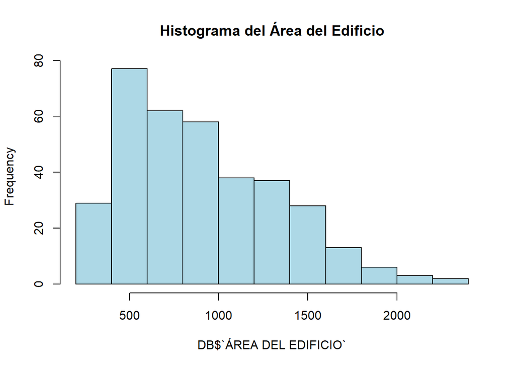

```r
# Análisis exploratorio
mean_area <- mean(DB$`ÁREA DEL EDIFICIO`)
var_area <- var(DB$`ÁREA DEL EDIFICIO`)
sd_area <- sd(DB$`ÁREA DEL EDIFICIO`)


# Eliminar empates
AE_unique <- unique(DB$`ÁREA DEL EDIFICIO`)

# Prueba de normalidad

shapiro_test <- shapiro.test(AE_unique)
ks_test <- ks.test(AE_unique, "pnorm")


# Histograma
hist(DB$`ÁREA DEL EDIFICIO`, breaks = "FD", col = "lightblue", main = "Histograma del Área del Edificio")
```

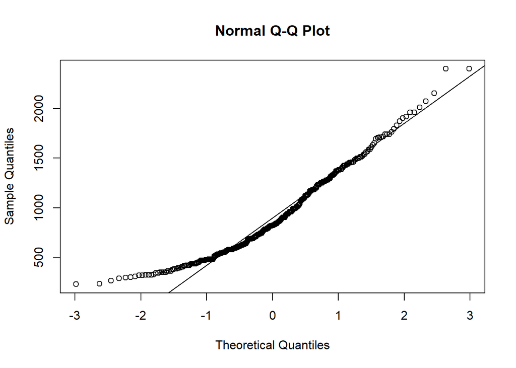

```r
# Gráfico Q-Q
qqnorm(DB$`ÁREA DEL EDIFICIO`)
qqline(DB$`ÁREA DEL EDIFICIO`)
```

```r
# Resultados
cat("Análisis exploratorio:\n")
```

```
## Análisis exploratorio:
```

```r
cat("Media:", mean_area, "\n")
```

```
## Media: 908.5042
```

```r
cat("Varianza:", var_area, "\n")
```

```
## Varianza: 184662.9
```

```r
cat("Desviación estándar:", sd_area, "\n\n")
```

```
## Desviación estándar: 429.7243
```

```r
cat("Prueba de normalidad:\n")
```

```
## Prueba de normalidad:
```

```r
cat("Prueba de Shapiro-Wilk:\n")
```

```
## Prueba de Shapiro-Wilk:
```

```r
print(shapiro_test)
```

```
##
##  Shapiro-Wilk normality test
##
## data:  AE_unique
## W = 0.96249, p-value = 2.46e-05
```

```r
cat("Prueba de Kolmogorov-Smirnov:\n")
```

```
## Prueba de Kolmogorov-Smirnov:
```

```r
print(ks_test)
```

```
##
##  One-sample Kolmogorov-Smirnov test
##
## data:  AE_unique
## D = 1, p-value < 2.2e-16
## alternative hypothesis: two-sided
```

**Analizamos “Ingreso estimado”**

```r
ingre <- table(DB$INGRESO)

summary(ingre)
```

```
## Number of cases in table: 353
## Number of factors: 1
```

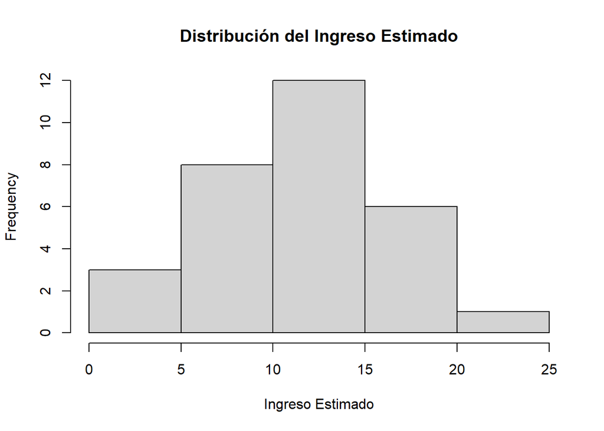

```r
hist(ingre, main = "Distribución del Ingreso Estimado", xlab = "Ingreso Estimado")
```

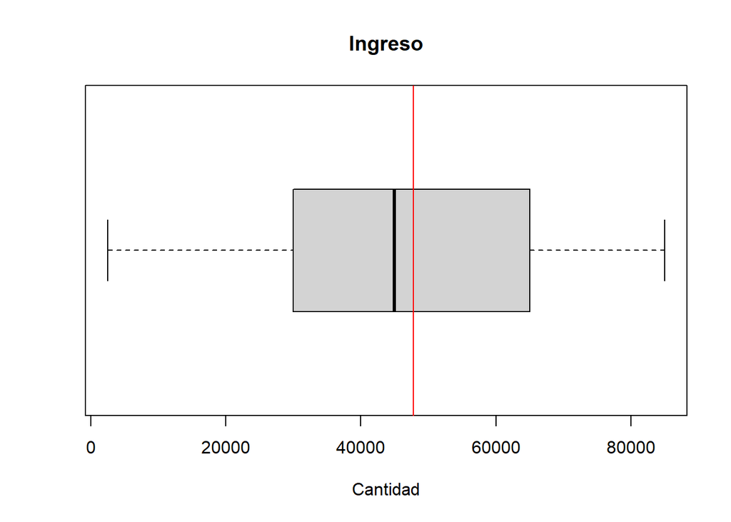

```r
boxplot(DF$INGRESO,main="Ingreso",horizontal=TRUE,xlab="Cantidad")
abline(v=mean(DF$INGRESO),col="red")
```

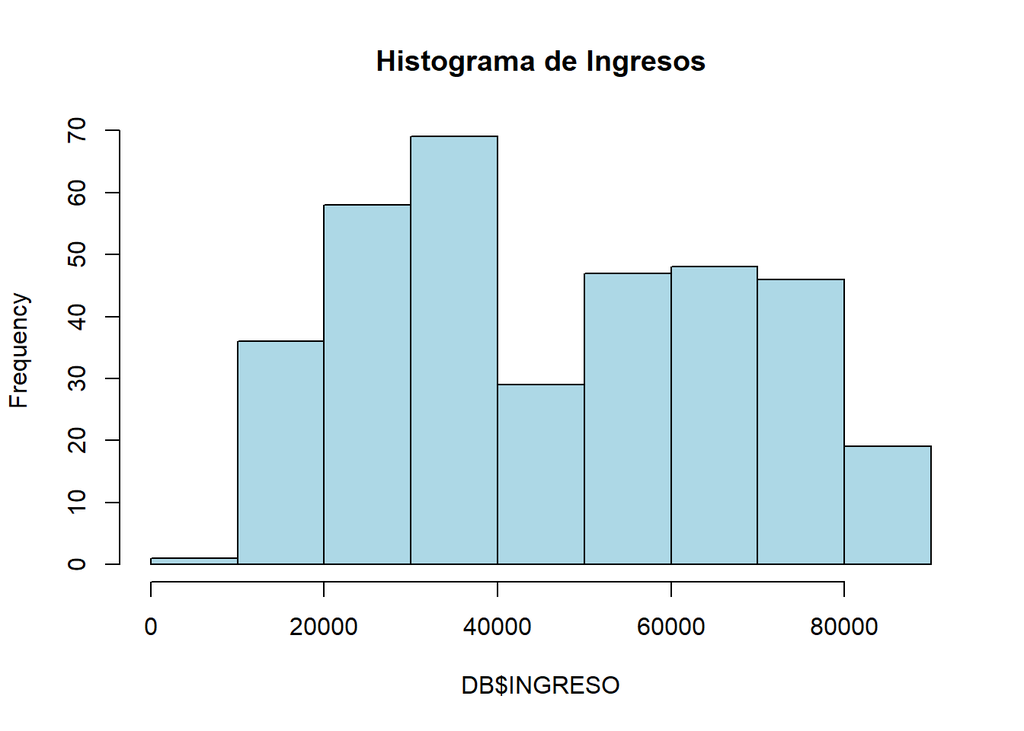

```r
# Análisis exploratorio
mean_ingreso <- mean(DB$INGRESO)
var_ingreso <- var(DB$INGRESO)
sd_ingreso <- sd(DB$INGRESO)

# Eliminar empates
I_unique <- unique(DB$INGRESO)

# Prueba de normalidad
shapiro_test <- shapiro.test(I_unique)
ks_test <- ks.test(I_unique, "pnorm")


# Histograma
hist(DB$INGRESO, breaks = "FD", col = "lightblue", main = "Histograma de Ingresos")
```

```r
# Resultados
cat("Análisis exploratorio:\n")
```

```
## Análisis exploratorio:
```

```r
cat("Media:", mean_ingreso, "\n")
```

```
## Media: 47818.7
```

```r
cat("Varianza:", var_ingreso, "\n")
```

```
## Varianza: 437344877
```

```r
cat("Desviación estándar:", sd_ingreso, "\n\n")
```

```
## Desviación estándar: 20912.79
```

```r
cat("Prueba de normalidad:\n")
```

```
## Prueba de normalidad:
```

```r
cat("Prueba de Shapiro-Wilk:\n")
```

```
## Prueba de Shapiro-Wilk:
```

```r
print(shapiro_test)
```

```
##
##  Shapiro-Wilk normality test
##
## data:  I_unique
## W = 0.97156, p-value = 0.5828
```

```r
cat("Prueba de Kolmogorov-Smirnov:\n")
```

```
## Prueba de Kolmogorov-Smirnov:
```

```r
print(ks_test)
```

```
##
##  One-sample Kolmogorov-Smirnov test
##
## data:  I_unique
## D = 1, p-value = 1.221e-15
## alternative hypothesis: two-sided
```

## **Conclusiones**

- Como conclusiones finales del proyecto, podemos destacar que hemos logrado identificar y seleccionar variables relevantes que determinan la viabilidad de proyectos de sistemas de detección y protección contra incendios en Lima. A través del análisis de datos, hemos descubierto relaciones importantes entre algunas de estas variables, lo que nos ha permitido aplicar filtros adicionales a nuestras observaciones y determinar cuáles proyectos son más viables.
- Este proceso de selección y filtrado nos proporciona una perspectiva más clara sobre los proyectos que presentan mayor potencial en términos de viabilidad y éxito. Al considerar factores como la ubicación, el tamaño del edificio y otros aspectos relevantes, hemos podido identificar las observaciones que cumplen con criterios más sólidos y se ajustan mejor a nuestras necesidades y capacidades empresariales.
- Estas conclusiones nos permiten optimizar nuestros recursos y enfocar nuestros esfuerzos en aquellos proyectos que tienen mayores posibilidades de generar resultados favorables. Al tener un conjunto de variables bien definido y encontrar relaciones significativas entre ellas, podemos tomar decisiones más informadas y estratégicas en cuanto a los proyectos que decidimos abordar.
- En resumen, este proyecto ha sido exitoso en la selección de variables clave y el análisis de relaciones relevantes, lo cual nos ha permitido refinar nuestras observaciones y determinar qué proyectos de sistemas contra incendios en Lima son más viables y prometedores para nuestro negocio. Estas conclusiones contribuyen a una toma de decisiones más fundamentada y nos posicionan de manera favorable para aprovechar las oportunidades de mercado en este campo.

## **BibliografÍa**

- RPubs - Gráficos univariados y bivariados. (n.d.). Rpubs.com. Retrieved June 5, 2023, from https://rpubs.com/jformoso/838661
- Soetewey, A. (s/f). An efficient way to install and load R packages. Stats and R. Recuperado el 4 de junio de 2023, de https://statsandr.com/blog/an-efficient-way-to-install-and-load-r-packages/